# script árvores compilado

### 🔴 Sugestão do professor:

Essa questão não foi abordada em aula, mas no nosso caso o modelo binomial fica instável porque, em alguns gêneros, nenhum indivíduo apresentou bifurcação. Além de terem um número relativamente baixo de indivíduos observados. Sendo assim, vale a pena fazer um filtro apenas para gêneros principais gerando um melhor modelo para o artigo.

```r
# Filtering the database
fabaceae <- arvore %>%
  filter(family == "Fabaceae", !is.na(genus), genus != "") %>%
  add_count(genus, name = "n_genus") %>%
  arrange(desc(n_genus), genus) %>%
  mutate(rank_genus = match(genus, unique(genus))) %>%
  filter(rank_genus <= 10) %>%
  mutate(genus = as.factor(genus)) %>%
  dplyr::select(-n_genus, -rank_genus) %>%
  droplevels()
```

```r
# Binomial model
mod_binom <- glm(multicaule ~ altura + genus, data = fabaceae, family = "binomial")
```

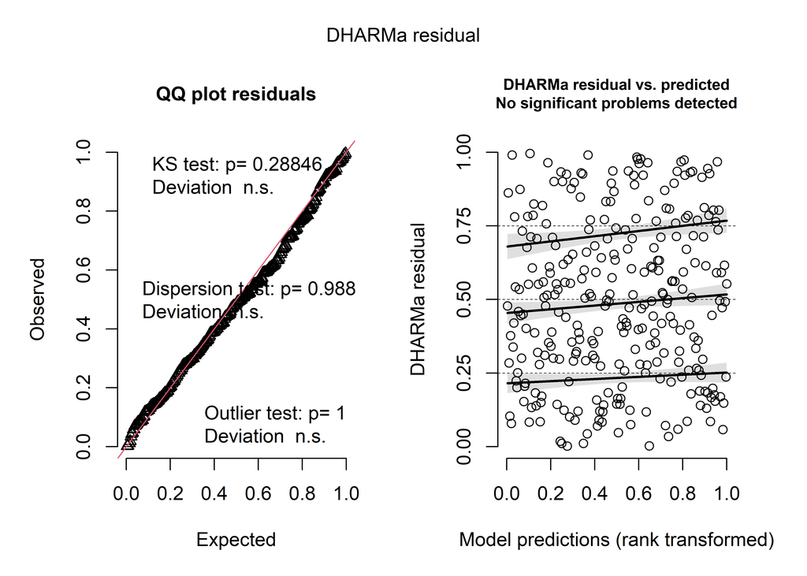

```r
# Analysis of residuals
res_mod_binom <- simulateResiduals(mod_binom, n = 1000)
plot(res_mod_binom)
```

```r
# Model analysis of deviance
anova(mod_binom, test = "Chisq")
```

```
## Analysis of Deviance Table
##
## Model: binomial, link: logit
##
## Response: multicaule
##
## Terms added sequentially (first to last)
##
##
##        Df Deviance Resid. Df Resid. Dev  Pr(>Chi)
## NULL                     283     292.88
## altura  1   15.881       282     277.00 6.746e-05 ***
## genus   9   20.015       273     256.98   0.01782 *
## ---
## Signif. codes:  0 '***' 0.001 '**' 0.01 '*' 0.05 '.' 0.1 ' ' 1
```

```r
# Model summary
summary(mod_binom)
```

```
##
## Call:
## glm(formula = multicaule ~ altura + genus, family = "binomial",
##     data = fabaceae)
##
## Coefficients:
##                   Estimate Std. Error z value Pr(>|z|)
## (Intercept)        1.24248    0.54928   2.262  0.02370 *
## altura            -0.07939    0.03604  -2.203  0.02762 *
## genusCassia       -1.58502    0.75463  -2.100  0.03569 *
## genusCentrolobium -1.87202    0.71252  -2.627  0.00861 **
## genusDalbergia    -0.87186    0.63607  -1.371  0.17047
## genusErythrina    -1.67254    0.74607  -2.242  0.02497 *
## genusHymenaea     -2.77835    1.19748  -2.320  0.02033 *
## genusLibidibia    -2.17278    0.91332  -2.379  0.01736 *
## genusMachaerium   -1.83350    0.80783  -2.270  0.02323 *
## genusPaubrasilia  -1.71286    0.57723  -2.967  0.00300 **
## genusPeltophorum  -2.73767    1.16283  -2.354  0.01856 *
## ---
## Signif. codes:  0 '***' 0.001 '**' 0.01 '*' 0.05 '.' 0.1 ' ' 1
##
## (Dispersion parameter for binomial family taken to be 1)
##
##     Null deviance: 292.88  on 283  degrees of freedom
## Residual deviance: 256.98  on 273  degrees of freedom
## AIC: 278.98
##
## Number of Fisher Scoring iterations: 5
```

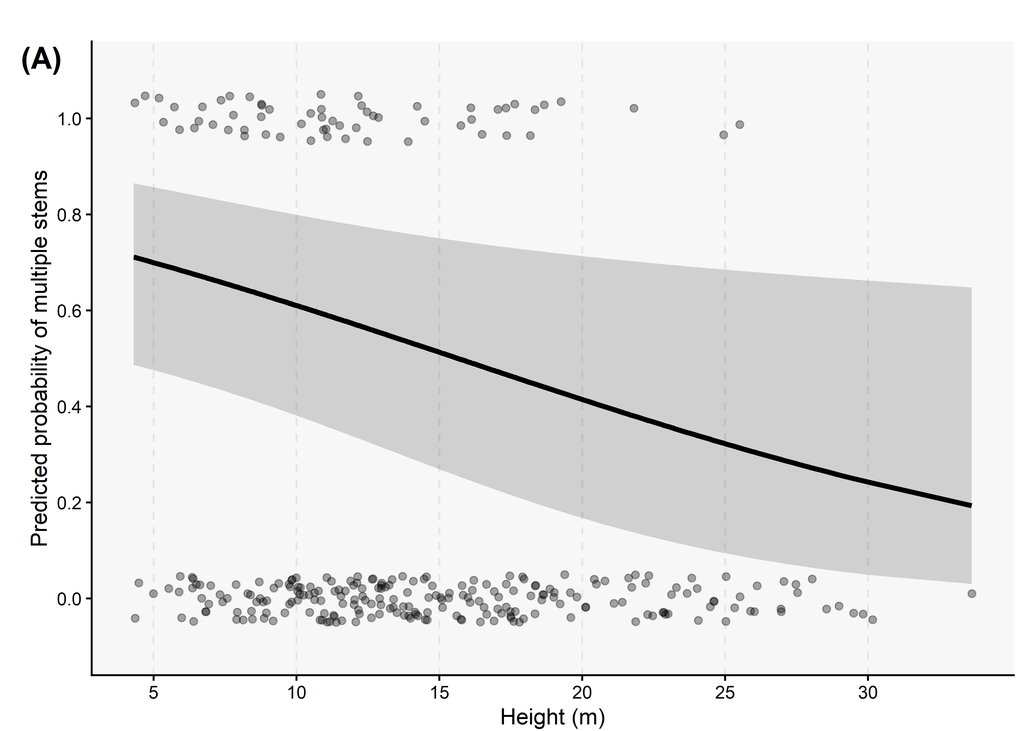

```r
# Predição média da probabilidade de multicaule em função da altura
pred_altura <- ggpredict(mod_binom, terms = "altura [all]", margin = "empirical")

# Visualizing
binom_alt <-
ggplot() +
  geom_jitter(data = fabaceae, aes(x = altura, y = multicaule), height = 0.05, width = 0.05, alpha = 0.35) +
  geom_ribbon(data = pred_altura, aes(x = x, ymin = conf.low, ymax = conf.high), alpha = 0.2) +
  geom_line(data = pred_altura, aes(x = x, y = predicted), linewidth = 1.2) +
  scale_y_continuous(limits = c(-0.1, 1.1), breaks = seq(0, 1, 0.2)) +
  scale_x_continuous(breaks = seq(0, 30, 5)) +
  labs(x = "Height (m)", y = "Predicted probability of multiple stems", title = "(A)") +
  theme_classic() +
  theme(panel.grid.major.x = element_line(color = "grey90", linetype = "dashed"),
        panel.background = element_rect(fill = "grey97"),
        plot.title = element_text(hjust = -0.01, vjust = -6, face = "bold", size = 15),
        plot.title.position = "plot",
        plot.margin = margin(1, 5, 1, 15))

binom_alt
```

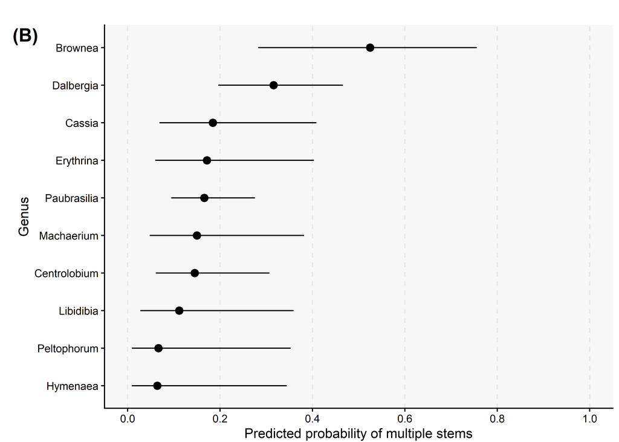

```r
# Predicting considering genus
pred_genus <- ggpredict(mod_binom, terms = "genus")

# Visualizing
binom_spe <-
ggplot(pred_genus, aes(x = reorder(x, predicted), y = predicted)) +
  geom_pointrange(aes(ymin = conf.low, ymax = conf.high)) +
  coord_flip() +
  scale_y_continuous(limits = c(0, 1), breaks = seq(0, 1, 0.2)) +
  labs(x = "Genus", y = "Predicted probability of multiple stems", title = "(B)") +
  theme_classic() +
  theme(panel.grid.major.x = element_line(color = "grey90", linetype = "dashed"),
        panel.background = element_rect(fill = "grey97"),
        plot.title = element_text(hjust = -0.01, vjust = -6, face = "bold", size = 15),
        plot.title.position = "plot",
        plot.margin = margin(1, 5, 1, 15))

binom_spe
```

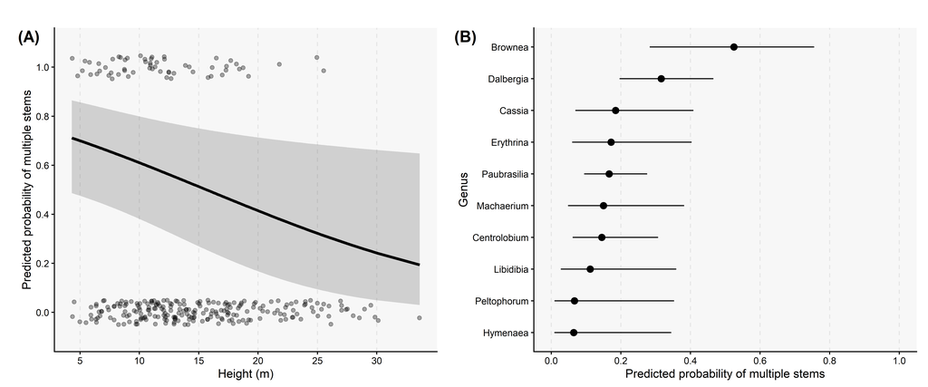

```r
# Joining plots
binom_alt + binom_spe
```

## 3.4. Seria possível modelar para descrever a relação entre altura e DAP para árvores ou pelo menos algumas das famílias?

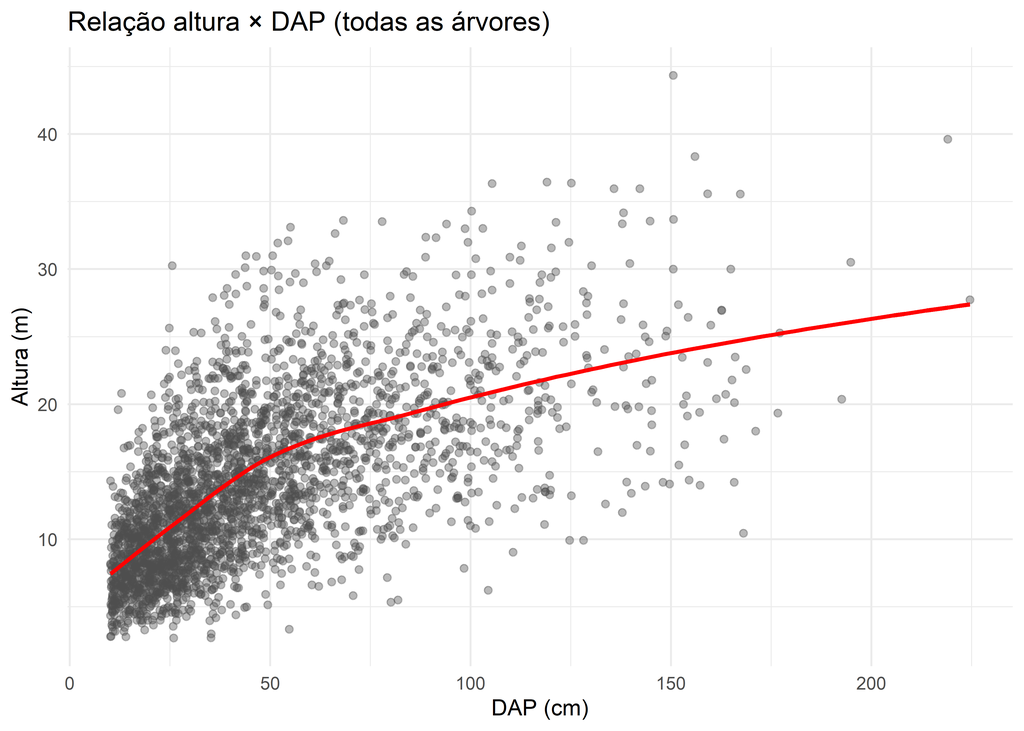

```r
# modelar para descrever a relação entre altura e DAP
ggplot(arvore, aes(x = dap, y = altura)) +
  geom_point(alpha = 0.4, color = "grey30") +
  geom_smooth(method = "loess", se = F, color = "red") +
  labs(title = "Relação altura × DAP (todas as árvores)",
       x = "DAP (cm)", y = "Altura (m)") +
  theme_minimal()
```

```r
# Removing NA and tranforming variables
arvore_mod <- arvore %>%
  filter(!is.na(altura),
    !is.na(dap),
    !is.na(n_caule),
    !is.na(multicaule),
    !is.na(sec_cant),
    !is.na(family)) %>%
  mutate(sec_cant = as.factor(sec_cant),
    family = as.factor(family),
    multicaule = as.factor(multicaule),
    genus = as.factor(genus))
```

```r
# Filtering the database for family represented by 10 or more plants
arvore_mod2 <- arvore_mod %>%
  filter(!is.na(family)) %>%
  add_count(family, name = "n_family") %>%
  filter(n_family >= 10) %>%
  dplyr::select(-n_family)
```

### 3.4.1. Height x DHB visualization

```r
# Counting 16 top families
contagem <- arvore_mod2 %>%
  filter(!is.na(family)) %>%
  count(family) %>%
  arrange(desc(n)) %>%
  slice_head(n = 16) %>%
  pull(family)

# Filtering
arv_16 <- arvore_mod2 %>%
  filter(family %in% contagem)
```

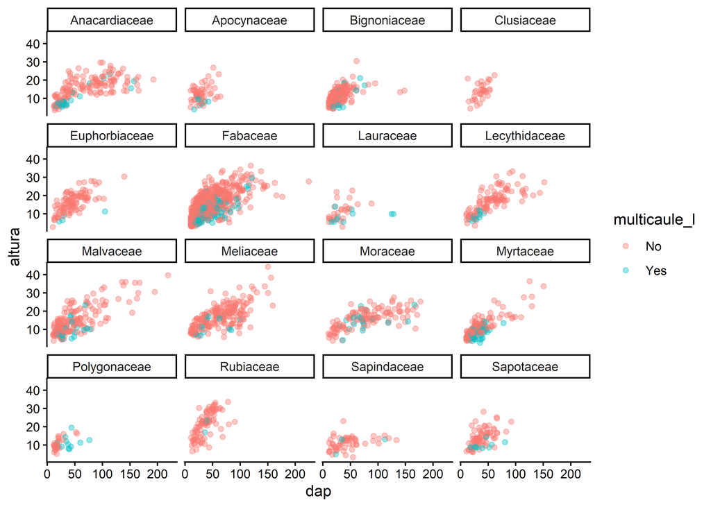

```r
# Visualizing
ggplot(arv_16, aes(x = dap, y = altura, color = multicaule_l)) +
  geom_point(alpha = 0.4) +
  facet_wrap(~family) +
  theme_classic()
```

### 3.4.2. Modeling for specific genus/families

### 🔴 Sugestão do professor:

Há, nesta seção, alguns erros menores que não comentarei individualmente. De modo geral, porém, foi realizada uma exploração extensa, demonstrando que a inclusão de grupos taxonômicos (ora famílias, ora gêneros) pode explicar melhor a relação entre altura e DAP. Alguns dos problemas identificados foram herdados do meu próprio script. Comentarei os mais importantes, mas me considero parcialmente responsável por eles, pois surgiram durante a adaptação do código.

Outra questão, o diagnóstico dos modelos foi realizado apenas com resíduos simulados do pacote DHARMa. Embora essa abordagem possa ser utilizada, para modelos lineares também é recomendável examinar os gráficos convencionais de resíduos, que permitem avaliar diretamente linearidade, homogeneidade da variância, normalidade e observações influentes. Esses diagnósticos devem complementar a comparação por AIC, BIC e R².

#### 3.4.2.1. Meliaceae

```r
# Filtering for genus and beds with more than 3 plants
meliaceae <- arvore_mod %>%
  filter(family == "Meliaceae") %>%
  filter(!is.na(genus)) %>%
  add_count(genus, name = "n_genus") %>%
  filter(n_genus >= 3) %>%
  add_count(sec_cant, name = "n_sec_cant") %>%
  filter(n_sec_cant >= 3) %>%
  dplyr::select(-n_genus, -n_sec_cant)
```

##### 3.4.2.1.1. Linear model

```r
# Linear model
mod1 <- lm(altura ~ dap + genus, data = meliaceae)
```

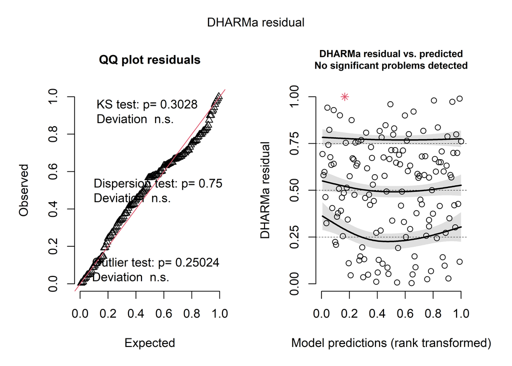

```r
# Analysis of residuals
res_mod1 <- simulateResiduals(mod1, n = 1000)
plot(res_mod1)
```

```r
# Linear model ANOVA
anova(mod1)
```

```
## Analysis of Variance Table
##
## Response: altura
##            Df Sum Sq Mean Sq F value    Pr(>F)
## dap         1 3440.9  3440.9 204.998 < 2.2e-16 ***
## genus       5  873.8   174.8  10.411 1.757e-08 ***
## Residuals 137 2299.6    16.8
## ---
## Signif. codes:  0 '***' 0.001 '**' 0.01 '*' 0.05 '.' 0.1 ' ' 1
```

```r
# Linear model summary
summary(mod1)
```

```
##
## Call:
## lm(formula = altura ~ dap + genus, data = meliaceae)
##
## Residuals:
##      Min       1Q   Median       3Q      Max
## -11.2384  -2.1809   0.6331   2.2191  18.6207
##
## Coefficients:
##                Estimate Std. Error t value Pr(>|t|)
## (Intercept)    10.08217    0.81413  12.384  < 2e-16 ***
## dap             0.13043    0.01111  11.739  < 2e-16 ***
## genusCedrela    2.30510    1.26207   1.826  0.06996 .
## genusGuarea    -3.82319    0.78735  -4.856 3.23e-06 ***
## genusKhaya      5.10954    1.90075   2.688  0.00808 **
## genusSwietenia  2.10772    1.33952   1.573  0.11791
## genusTrichilia -1.42174    2.43383  -0.584  0.56008
## ---
## Signif. codes:  0 '***' 0.001 '**' 0.01 '*' 0.05 '.' 0.1 ' ' 1
##
## Residual standard error: 4.097 on 137 degrees of freedom
## Multiple R-squared:  0.6523, Adjusted R-squared:  0.6371
## F-statistic: 42.84 on 6 and 137 DF,  p-value: < 2.2e-16
```

##### 3.4.2.1.2. Log model

```r
# Log model
mod_log <- lm(altura ~ log(dap) + genus, data = meliaceae)
```

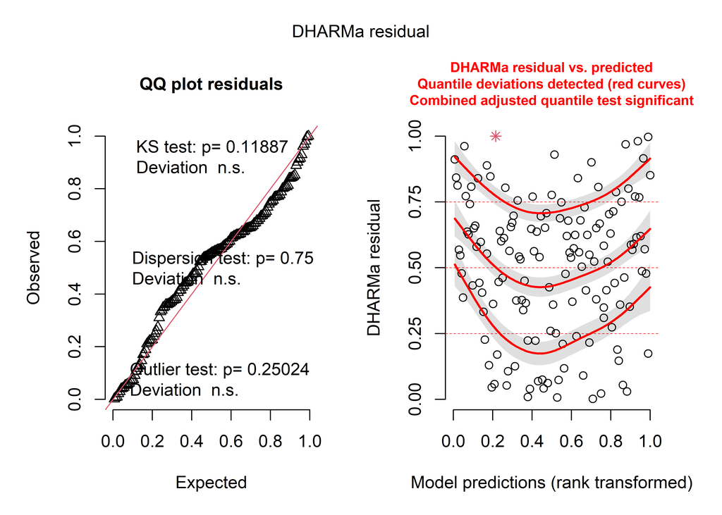

```r
# Analysis of residuals
res_mod_log <- simulateResiduals(mod_log, n = 1000)
plot(res_mod_log)
```

##### 3.4.2.1.3. Quadratic model

```r
# Quadratic model
mod2 <- lm(altura ~ dap + I(dap^2) + genus, data = meliaceae)
```

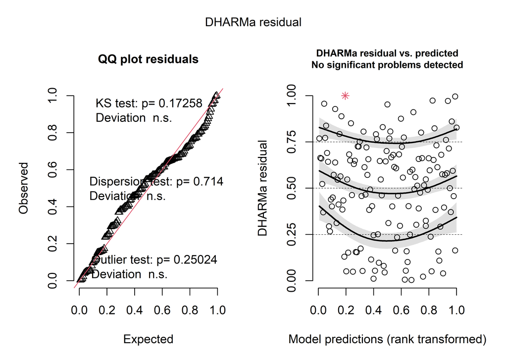

```r
# Analysis of residuals
res_mod2 <- simulateResiduals(mod2, n = 1000)
plot(res_mod2)
```

```r
# Quadratic model ANOVA
anova(mod2)
```

```
## Analysis of Variance Table
##
## Response: altura
##            Df Sum Sq Mean Sq  F value    Pr(>F)
## dap         1 3440.9  3440.9 206.2544 < 2.2e-16 ***
## I(dap^2)    1   46.3    46.3   2.7728   0.09818 .
## genus       5  858.2   171.6  10.2883 2.214e-08 ***
## Residuals 136 2268.9    16.7
## ---
## Signif. codes:  0 '***' 0.001 '**' 0.01 '*' 0.05 '.' 0.1 ' ' 1
```

##### 3.4.2.1.4. Comparing models

```r
# ANOVA for comparing linear, quadratic and log regression models
anova(mod1, mod2, mod_log)
```

```
## Analysis of Variance Table
##
## Model 1: altura ~ dap + genus
## Model 2: altura ~ dap + I(dap^2) + genus
## Model 3: altura ~ log(dap) + genus
##   Res.Df    RSS Df Sum of Sq      F Pr(>F)
## 1    137 2299.6
## 2    136 2268.9  1    30.688 1.8395 0.1773
## 3    137 2209.8 -1    59.097
```

```r
# AIC and BIC for model comparison
AIC(mod1, mod2, mod_log)
```

```
##         df      AIC
## mod1     8 823.6298
## mod2     9 823.6951
## mod_log  8 817.8947
```

```r
BIC(mod1, mod2, mod_log)
```

```
##         df      BIC
## mod1     8 847.3883
## mod2     9 850.4234
## mod_log  8 841.6532
```

```r
# Linear model R²
r2(mod1)
```

```
## # R2 for Linear Regression
##        R2: 0.652
##   adj. R2: 0.637
```

```r
# log model R²
r2(mod_log)
```

```
## # R2 for Linear Regression
##        R2: 0.666
##   adj. R2: 0.651
```

### 🔴 Sugestão do professor:

A comparação conjunta por anova() não é válida porque o modelo logarítmico não é aninhado nos modelos linear e quadrático. Esse mesmo erro é reproduzido outras vezes na comparação entre outros modelos. A ANOVA pode ser utilizada apenas para comparar os modelos linear e quadrático. Para comparar os três, devem ser utilizados AIC, BIC e o diagnóstico dos resíduos. Nesse caso, AIC e BIC indicam melhor ajuste do modelo logarítmico. O ideal seria separar os modelos aninhados para comparação por anova():

```r
# Comparando modelo linear e quadrático
anova(mod1, mod2)
```

```
## Analysis of Variance Table
##
## Model 1: altura ~ dap + genus
## Model 2: altura ~ dap + I(dap^2) + genus
##   Res.Df    RSS Df Sum of Sq      F Pr(>F)
## 1    137 2299.6
## 2    136 2268.9  1    30.688 1.8395 0.1773
```

##### 3.4.2.1.5. Visualizing results

```r
library(multcomp)
library(multcompView)
```

```r
# Means comparison between species - não funcionou. Error in UseMethod("cld") :  método não aplicável para 'cld' aplicado a um objeto de classe "emmGrid" - resolvido ao transformar 'genus' em factor, antes estava como character. necessário fazer essa mudança para trabalhar com Famílias e não necessário para trabalhar com gêneros já que genus não é uma variável utilizada.
emm_sp <- emmeans(mod_log, ~ genus)

multcomp::cld(emm_sp, adjust = "sidak", Letters = letters, decreasing = T)
```

```
##  genus     emmean    SE  df lower.CL upper.CL .group
##  Khaya       28.3 1.660 137     23.9     32.7  a
##  Cedrela     22.0 1.110 137     19.0     25.0   b
##  Swietenia   21.6 1.220 137     18.3     24.8   b
##  Carapa      19.2 0.526 137     17.8     20.6   b
##  Trichilia   17.0 2.340 137     10.8     23.3   bc
##  Guarea      15.4 0.586 137     13.9     17.0    c
##
## Confidence level used: 0.95
## Conf-level adjustment: sidak method for 6 estimates
## P value adjustment: sidak method for 15 tests
## significance level used: alpha = 0.05
## NOTE: If two or more means share the same grouping symbol,
##       then we cannot show them to be different.
##       But we also did not show them to be the same.
```

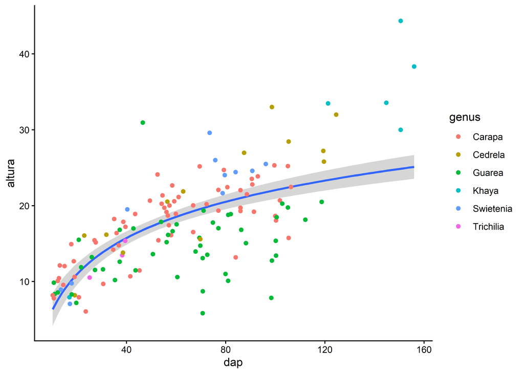

```r
ggplot(data = meliaceae, aes(x = dap, y = altura)) +
  geom_smooth(method = "lm", formula = y ~ log(x)) +
  geom_point(aes(color = genus)) +
  theme_classic()
```

### 🔴 Sugestão do professor:

O gráfico não representa completamente o modelo selecionado. Embora o modelo inclua o efeito de gênero, geom_smooth() apresenta apenas uma curva geral, ignorando esse efeito. As predições devem ser apresentadas separadamente por gênero ou o gráfico deve ser identificado apenas como uma visualização exploratória da relação entre altura e DAP.

#### 3.4.2.2. Carapa - Meliaceae genus

```r
carapa <- arvore %>%
  filter(genus == "Carapa")
```

##### 3.4.2.2.1. Linear model

```r
# Linear model
mod1c <- lm(altura ~ dap, data = carapa)
```

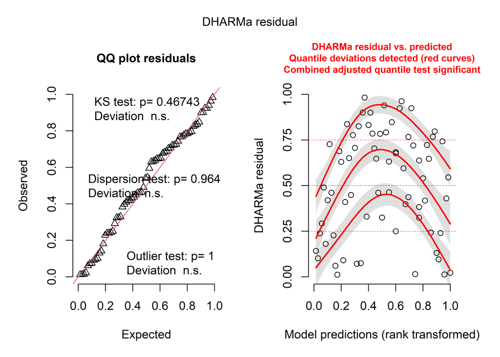

```r
# Analysis of residuals
res_mod1c <- simulateResiduals(mod1c, n = 1000)
plot(res_mod1c)
```

##### 3.4.2.2.2. Log model

```r
# Log model
mod_logc <- lm(altura ~ log(dap), data = carapa)
```

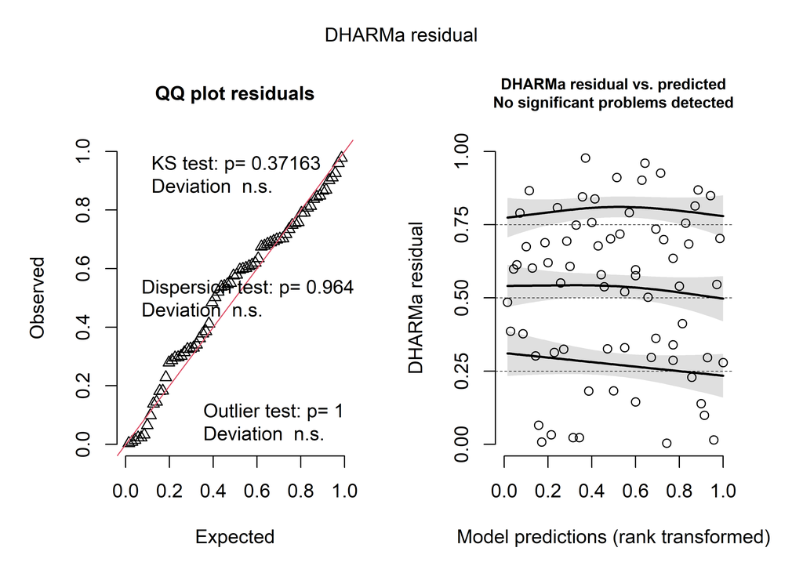

```r
# Analysis of residuals
res_mod_logc <- simulateResiduals(mod_logc, n = 1000)
plot(res_mod_logc)
```

```r
# log model ANOVA
anova(mod_logc)
```

```
## Analysis of Variance Table
##
## Response: altura
##           Df  Sum Sq Mean Sq F value    Pr(>F)
## log(dap)   1 1085.46 1085.46  128.41 < 2.2e-16 ***
## Residuals 68  574.82    8.45
## ---
## Signif. codes:  0 '***' 0.001 '**' 0.01 '*' 0.05 '.' 0.1 ' ' 1
```

```r
# log model summary
summary(mod_logc)
```

```
##
## Call:
## lm(formula = altura ~ log(dap), data = carapa)
##
## Residuals:
##     Min      1Q  Median      3Q     Max
## -7.7276 -1.3830  0.5576  1.7663  6.0275
##
## Coefficients:
##             Estimate Std. Error t value Pr(>|t|)
## (Intercept)  -5.6538     2.1018   -2.69  0.00898 **
## log(dap)      5.9965     0.5292   11.33  < 2e-16 ***
## ---
## Signif. codes:  0 '***' 0.001 '**' 0.01 '*' 0.05 '.' 0.1 ' ' 1
##
## Residual standard error: 2.907 on 68 degrees of freedom
## Multiple R-squared:  0.6538, Adjusted R-squared:  0.6487
## F-statistic: 128.4 on 1 and 68 DF,  p-value: < 2.2e-16
```

##### 3.4.2.2.3. Quadratic model

```r
# Quadratic model
mod2c <- lm(altura ~ dap + I(dap^2), data = carapa)
```

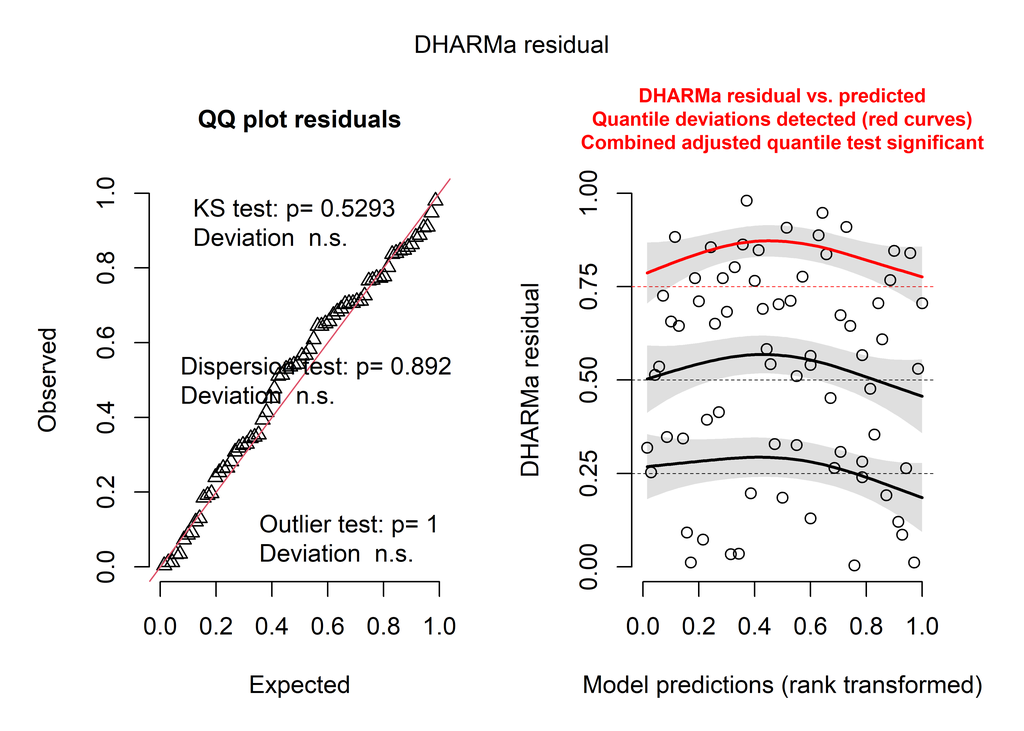

```r
# Analysis of residuals
res_mod2c <- simulateResiduals(mod2c, n = 1000)
plot(res_mod2c)
```

### 🔴 Sugestão do professor:

Foram ajustados modelos linear, logarítmico e quadrático, mas não foi apresentada a comparação entre eles antes da escolha do modelo logarítmico para inclusão do efeito aleatório de canteiro. Primeiro, comparem as três formas por AIC, BIC e diagnóstico dos resíduos. Depois, incluam o efeito de canteiro no modelo com a forma funcional selecionada.

```r
# Comparação por AIC
AIC(mod1c, mod_logc, mod2c)
```

```
##          df      AIC
## mod1c     3 369.4767
## mod_logc  3 352.0407
## mod2c     4 353.9245
```

```r
# Comparação por BIC
BIC(mod1c, mod_logc, mod2c)
```

```
##          df      BIC
## mod1c     3 376.2222
## mod_logc  3 358.7861
## mod2c     4 362.9185
```

##### 3.4.2.2.4. Mixed effects log model

```r
# log model with beds random effects
mod1m <- lmer(altura ~ log(dap) + (1 | sec_cant), data = carapa, REML = T)
```

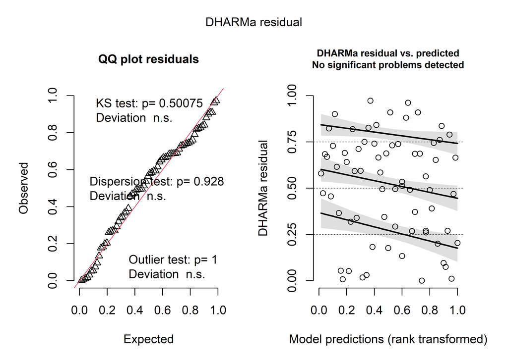

```r
# Analysis of residuals
res_mod1m <- simulateResiduals(mod1m, n = 1000)
plot(res_mod1m)
```

```r
# Comparing models without and with random effects
AIC(mod_logc, mod1m)
```

```
##          df      AIC
## mod_logc  3 352.0407
## mod1m     4 350.3749
```

```r
BIC(mod_logc, mod1m)
```

```
##          df      BIC
## mod_logc  3 358.7861
## mod1m     4 359.3689
```

### 🔴 Sugestão do professor:

Há um problema nessa comparação também. mod1m foi ajustado com REML = TRUE, e seu AIC foi comparado diretamente ao do lm. Para essa comparação, eu orientaria ajustar temporariamente o modelo misto por máxima verossimilhança:

```r
# Ajuste do modelo por máxima verossimilhança
mod1m_ml <- lmer(altura ~ log(dap) + (1 | sec_cant), data = carapa, REML = FALSE)

# AIC
AIC(mod_logc, mod1m_ml)
```

```
##          df      AIC
## mod_logc  3 352.0407
## mod1m_ml  4 351.1160
```

```r
# BIC
BIC(mod_logc, mod1m_ml)
```

```
##          df      BIC
## mod_logc  3 358.7861
## mod1m_ml  4 360.1100
```

```r
# log model R²
r2(mod_logc)
```

```
## # R2 for Linear Regression
##        R2: 0.654
##   adj. R2: 0.649
```

```r
# mixed model R²
r2(mod1m)
```

```
## # R2 for Mixed Models
##
##   Conditional R2: 0.728
##      Marginal R2: 0.679
```

```r
# Mixed model summary
summary(mod1m)
```

```
## Linear mixed model fit by REML. t-tests use Satterthwaite's method [
## lmerModLmerTest]
## Formula: altura ~ log(dap) + (1 | sec_cant)
##    Data: carapa
##
## REML criterion at convergence: 342.4
##
## Scaled residuals:
##     Min      1Q  Median      3Q     Max
## -2.2772 -0.5604  0.1487  0.6683  1.9891
##
## Random effects:
##  Groups   Name        Variance Std.Dev.
##  sec_cant (Intercept) 1.307    1.143
##  Residual             7.130    2.670
## Number of obs: 70, groups:  sec_cant, 18
##
## Fixed effects:
##             Estimate Std. Error      df t value Pr(>|t|)
## (Intercept)  -7.0890     2.1661 65.4580  -3.273   0.0017 **
## log(dap)      6.3814     0.5359 67.6768  11.908   <2e-16 ***
## ---
## Signif. codes:  0 '***' 0.001 '**' 0.01 '*' 0.05 '.' 0.1 ' ' 1
##
## Correlation of Fixed Effects:
##          (Intr)
## log(dap) -0.979
```

```r
# Mixed model summary
anova(mod1m)
```

```
## Type III Analysis of Variance Table with Satterthwaite's method
##          Sum Sq Mean Sq NumDF  DenDF F value    Pr(>F)
## log(dap) 1010.9  1010.9     1 67.677  141.79 < 2.2e-16 ***
## ---
## Signif. codes:  0 '***' 0.001 '**' 0.01 '*' 0.05 '.' 0.1 ' ' 1
```

```r
# Random effects significance
ranova(mod1m)
```

```
## ANOVA-like table for random-effects: Single term deletions
##
## Model:
## altura ~ log(dap) + (1 | sec_cant)
##                npar  logLik    AIC    LRT Df Pr(>Chisq)
## <none>            4 -171.19 350.37
## (1 | sec_cant)    3 -172.89 351.78 3.4059  1    0.06496 .
## ---
## Signif. codes:  0 '***' 0.001 '**' 0.01 '*' 0.05 '.' 0.1 ' ' 1
```

### 🔴 Sugestão do professor:

Embora os valores de R² marginal e condicional tenham sido superiores no modelo misto, o efeito de canteiro apresentou evidência apenas marginal (p = 0,065), e AIC e BIC não indicaram de forma consistente a superioridade desse modelo. Portanto, os efeitos estimados para os canteiros devem ser interpretados com cautela. Outra possibilidade seria testar a inclusão do efeito aleatório de canteiro em modelos com outras formas para a relação entre altura e DAP, especialmente a quadrática, e comparar seus ajustes.

##### 3.4.2.2.5. Results visualization

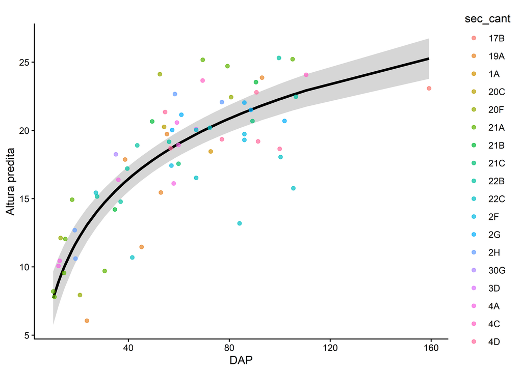

```r
# Predicting for plotting
pred_mod1m <- ggpredict(mod1m, terms = "dap [all]", type = "fixed")

# Visualizing
ggplot(pred_mod1m, aes(x = x, y = predicted)) +
  geom_ribbon(aes(ymin = conf.low, ymax = conf.high), alpha = 0.2) +
  geom_line(linewidth = 1.2) +
  geom_point(data = carapa, aes(x = dap, y = altura, color = sec_cant), inherit.aes = FALSE, alpha = 0.7) +
  labs(x = "DAP", y = "Altura predita", title = "") +
  theme_classic()
```

```r
# Extraindo efeitos aleatórios dos canteiros
rank_canteiros <- ranef(mod1m)$sec_cant %>%
  as.data.frame() %>%
  rownames_to_column("sec_cant") %>%
  rename(efeito_canteiro = `(Intercept)`) %>%
  arrange(desc(efeito_canteiro)) %>%
  mutate(rank = row_number(), interpretacao = case_when(
      efeito_canteiro > 0 ~ "Acima da média",
      efeito_canteiro < 0 ~ "Abaixo da média",
      TRUE ~ "Na média"))
```

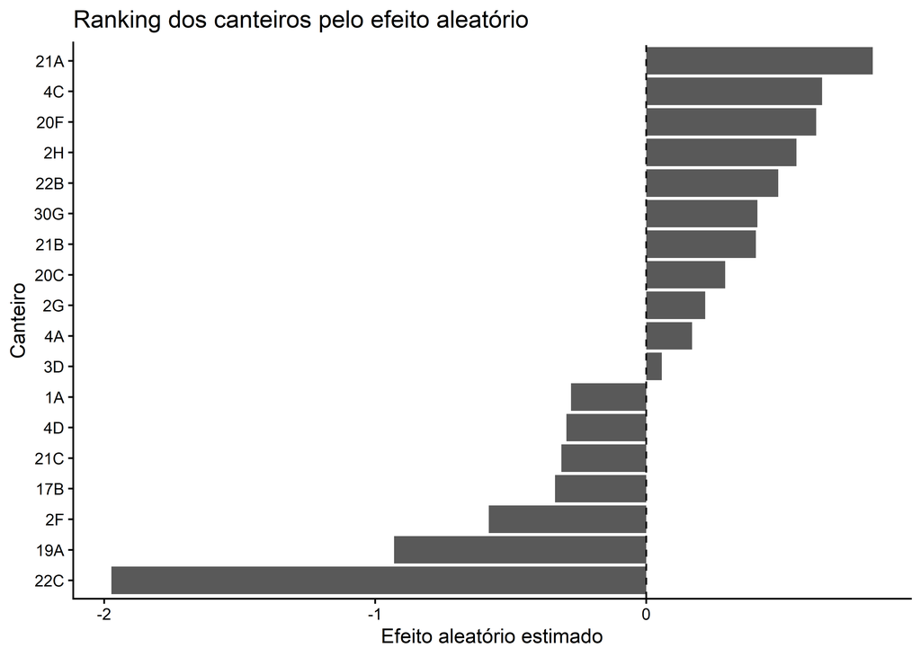

```r
# Visualizando
ggplot(rank_canteiros, aes(x = reorder(sec_cant, efeito_canteiro), y = efeito_canteiro)) +
  geom_col() +
  geom_hline(yintercept = 0, linetype = "dashed") +
  coord_flip() +
  labs(x = "Canteiro", y = "Efeito aleatório estimado", title = "Ranking dos canteiros pelo efeito aleatório") +
  theme_classic()
```

### 🔴 Sugestão do professor:

Gostei dos resultados dos modelos para andiroba. É uma espécie de interesse econômico pela madeira e óleo das sementes. Acredito ser um bom caminho refinarmos esse modelo para o artigo ilustrando os conceitos que vimos sobre modelos mistos.

#### 3.4.2.3. Bignoniaceae

```r
# Filtering database
bignoniaceae <- arvore %>%
  filter(family == "Bignoniaceae", !is.na(genus), genus != "", !is.na(sec_cant), sec_cant != "") %>%
  add_count(genus, name = "n_genus") %>%
  filter(n_genus >= 3) %>%
  dplyr::select(-n_genus) %>%
  add_count(sec_cant, name = "n_sec_cant") %>%
  filter(n_sec_cant >= 4) %>%
  dplyr::select(-n_sec_cant) %>%
  add_count(genus, name = "n_genus_final") %>%
  filter(n_genus_final >= 3) %>%
  dplyr::select(-n_genus_final)
```

##### 3.4.2.3.1. Linear model

```r
# Linear model
mod1b <- lm(altura ~ dap + genus, data = bignoniaceae)
```

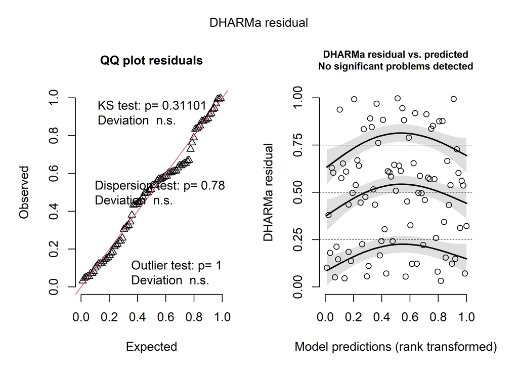

```r
# Analysis of residuals
res_mod1b <- simulateResiduals(mod1b, n = 1000)
plot(res_mod1b)
```

```r
# Model ANOVA
anova(mod1b)
```

```
## Analysis of Variance Table
##
## Response: altura
##           Df Sum Sq Mean Sq F value    Pr(>F)
## dap        1 328.35  328.35 42.9886 4.397e-09 ***
## genus      3  20.88    6.96  0.9111    0.4393
## Residuals 83 633.96    7.64
## ---
## Signif. codes:  0 '***' 0.001 '**' 0.01 '*' 0.05 '.' 0.1 ' ' 1
```

```r
# Linear model without genus
mod1b_alt <- lm(altura ~ dap, data = bignoniaceae)
```

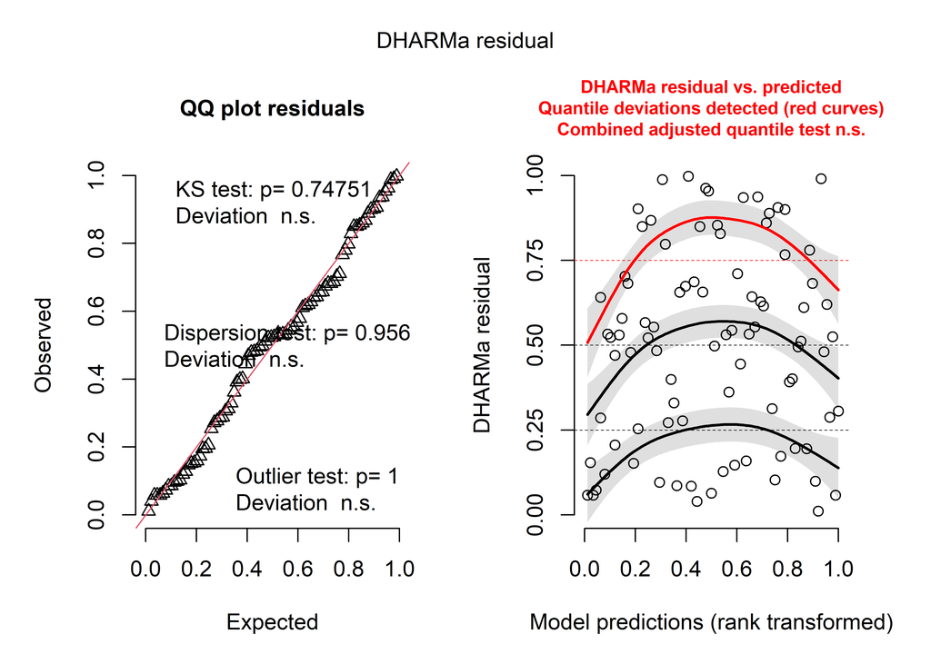

```r
# Analysis of residuals
res_mod1b_alt <- simulateResiduals(mod1b_alt, n = 1000)
plot(res_mod1b_alt)
```

```r
# Simple linear model summary
summary(mod1b_alt)
```

```
##
## Call:
## lm(formula = altura ~ dap, data = bignoniaceae)
##
## Residuals:
##     Min      1Q  Median      3Q     Max
## -6.3836 -1.8889  0.1277  1.4021  7.1085
##
## Coefficients:
##             Estimate Std. Error t value Pr(>|t|)
## (Intercept)  7.78386    0.70153  11.095  < 2e-16 ***
## dap          0.13484    0.02053   6.567 3.74e-09 ***
## ---
## Signif. codes:  0 '***' 0.001 '**' 0.01 '*' 0.05 '.' 0.1 ' ' 1
##
## Residual standard error: 2.759 on 86 degrees of freedom
## Multiple R-squared:  0.334,  Adjusted R-squared:  0.3262
## F-statistic: 43.12 on 1 and 86 DF,  p-value: 3.738e-09
```

##### 3.4.2.3.2. Log model

```r
# Log model
mod_logb <- lm(altura ~ log(dap) + genus, data = bignoniaceae)
```

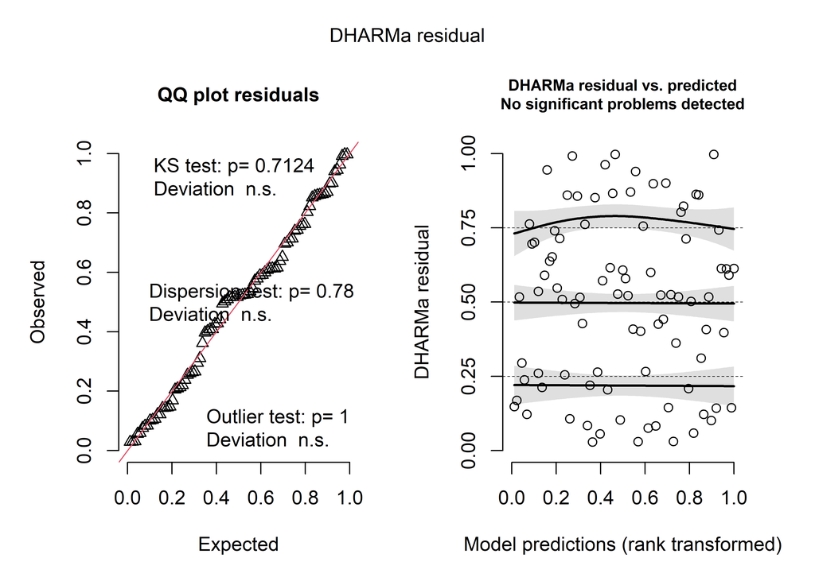

```r
# Analysis of residuals
res_mod_logb <- simulateResiduals(mod_logb, n = 1000)
plot(res_mod_logb)
```

```r
# log model ANOVA
anova(mod_logb)
```

```
## Analysis of Variance Table
##
## Response: altura
##           Df Sum Sq Mean Sq F value    Pr(>F)
## log(dap)   1 381.58  381.58 53.9884 1.274e-10 ***
## genus      3  14.98    4.99  0.7066    0.5507
## Residuals 83 586.62    7.07
## ---
## Signif. codes:  0 '***' 0.001 '**' 0.01 '*' 0.05 '.' 0.1 ' ' 1
```

```r
# Simple log model
mod_logb_alt <- lm(altura ~ log(dap), data = bignoniaceae)
```

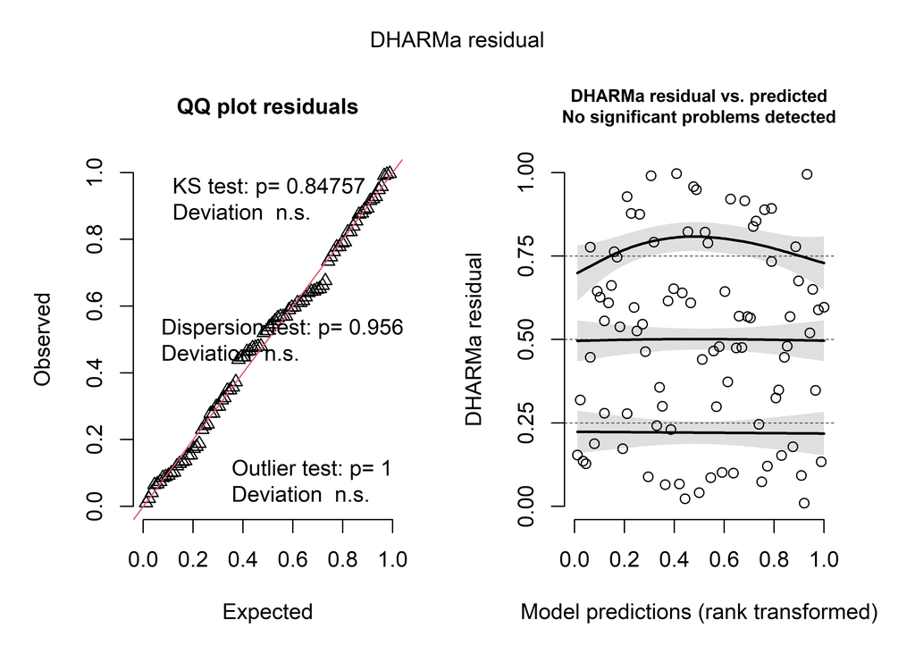

```r
# Analysis of residuals
res_mod_logb_alt <- simulateResiduals(mod_logb_alt, n = 1000)
plot(res_mod_logb_alt)
```

```r
# Simple log summary
summary(mod_logb_alt)
```

```
##
## Call:
## lm(formula = altura ~ log(dap), data = bignoniaceae)
##
## Residuals:
##     Min      1Q  Median      3Q     Max
## -6.3444 -1.7306  0.1345  1.7266  6.9133
##
## Coefficients:
##             Estimate Std. Error t value Pr(>|t|)
## (Intercept)  -3.1816     2.0703  -1.537    0.128
## log(dap)      4.5468     0.6156   7.386 9.09e-11 ***
## ---
## Signif. codes:  0 '***' 0.001 '**' 0.01 '*' 0.05 '.' 0.1 ' ' 1
##
## Residual standard error: 2.645 on 86 degrees of freedom
## Multiple R-squared:  0.3881, Adjusted R-squared:  0.381
## F-statistic: 54.55 on 1 and 86 DF,  p-value: 9.092e-11
```

##### 3.4.2.3.3. Quadratic model

```r
# Quadratic model
mod2b <- lm(altura ~ dap + I(dap^2) + genus, data = bignoniaceae)
```

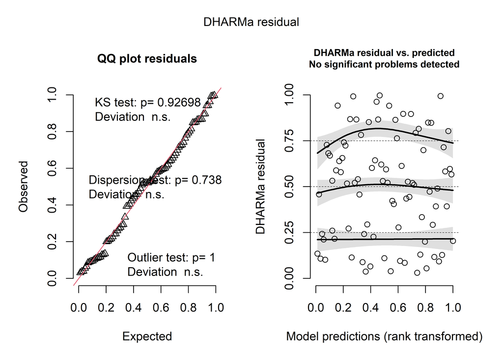

```r
# Analysis of residuals
res_mod2b <- simulateResiduals(mod2b, n = 1000)
plot(res_mod2b)
```

```r
# Quadratic model ANOVA
anova(mod2b)
```

```
## Analysis of Variance Table
##
## Response: altura
##           Df Sum Sq Mean Sq F value    Pr(>F)
## dap        1 328.35  328.35 44.8526 2.464e-09 ***
## I(dap^2)   1  40.39   40.39  5.5175   0.02123 *
## genus      3  14.15    4.72  0.6444   0.58868
## Residuals 82 600.29    7.32
## ---
## Signif. codes:  0 '***' 0.001 '**' 0.01 '*' 0.05 '.' 0.1 ' ' 1
```

```r
# Simple quadratic model
mod2b_alt <- lm(altura ~ dap + I(dap^2), data = bignoniaceae)
```

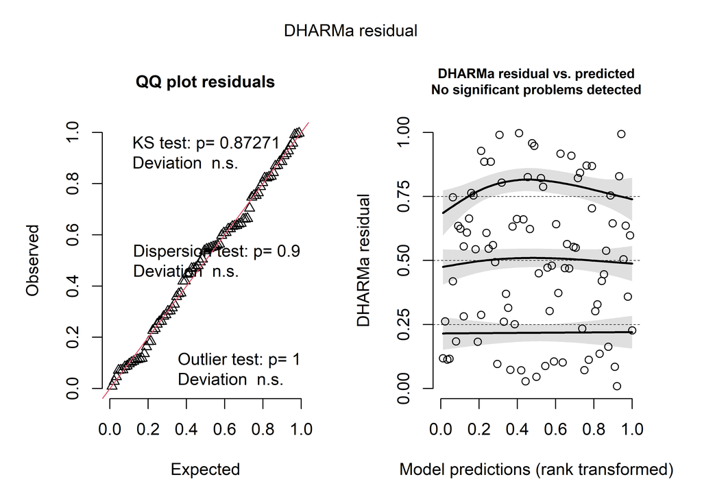

```r
# Analysis of residuals
res_mod2b_alt <- simulateResiduals(mod2b_alt, n = 1000)
plot(res_mod2b_alt)
```

##### 3.4.2.3.4. Model comparison

```r
# ANOVA for comparing log and quadratic regression models
anova(mod_logb_alt, mod2b_alt)
```

```
## Analysis of Variance Table
##
## Model 1: altura ~ log(dap)
## Model 2: altura ~ dap + I(dap^2)
##   Res.Df    RSS Df Sum of Sq F Pr(>F)
## 1     86 601.60
## 2     85 614.44  1   -12.837
```

```r
# Model comparison
AIC(mod_logb_alt, mod2b_alt)
```

```
##              df      AIC
## mod_logb_alt  3 424.8924
## mod2b_alt     4 428.7503
```

```r
BIC(mod_logb_alt, mod2b_alt)
```

```
##              df      BIC
## mod_logb_alt  3 432.3244
## mod2b_alt     4 438.6596
```

```r
# log model R²
r2(mod_logb_alt)
```

```
## # R2 for Linear Regression
##        R2: 0.388
##   adj. R2: 0.381
```

```r
# Quadratic model R²
r2(mod2b_alt)
```

```
## # R2 for Linear Regression
##        R2: 0.375
##   adj. R2: 0.360
```

##### 3.4.2.3.5. Mixed effects log model

```r
# Model with beds as random effects
mod1mb <- lmer(altura ~ log(dap) + (1 | sec_cant), data = bignoniaceae)
```

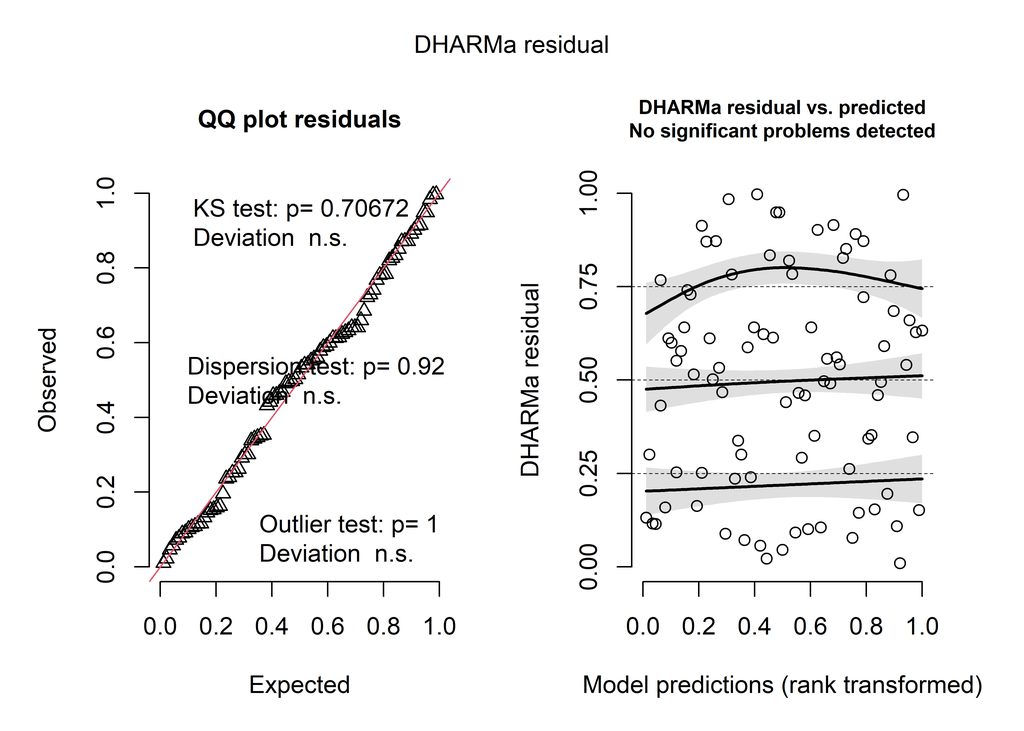

```r
# Analysis of residuals
res_mod1mb <- simulateResiduals(mod1mb, n = 1000)
plot(res_mod1mb)
```

```r
# Model ANOVA
anova(mod1mb)
```

```
## Type III Analysis of Variance Table with Satterthwaite's method
##          Sum Sq Mean Sq NumDF  DenDF F value    Pr(>F)
## log(dap) 293.46  293.46     1 85.758  48.032 7.344e-10 ***
## ---
## Signif. codes:  0 '***' 0.001 '**' 0.01 '*' 0.05 '.' 0.1 ' ' 1
```

```r
# Model R²
r2(mod1mb)
```

```
## # R2 for Mixed Models
##
##   Conditional R2: 0.456
##      Marginal R2: 0.355
```

```r
# Random effects significance
ranova(mod1mb)
```

```
## ANOVA-like table for random-effects: Single term deletions
##
## Model:
## altura ~ log(dap) + (1 | sec_cant)
##                npar  logLik    AIC    LRT Df Pr(>Chisq)
## <none>            4 -207.80 423.60
## (1 | sec_cant)    3 -209.37 424.74 3.1432  1    0.07624 .
## ---
## Signif. codes:  0 '***' 0.001 '**' 0.01 '*' 0.05 '.' 0.1 ' ' 1
```

```r
# Model comparison
AIC(mod_logb_alt, mod1mb)
```

```
##              df      AIC
## mod_logb_alt  3 424.8924
## mod1mb        4 423.5988
```

```r
BIC(mod_logb_alt, mod1mb)
```

```
##              df      BIC
## mod_logb_alt  3 432.3244
## mod1mb        4 433.5081
```

##### 3.4.2.3.6. Results visualization

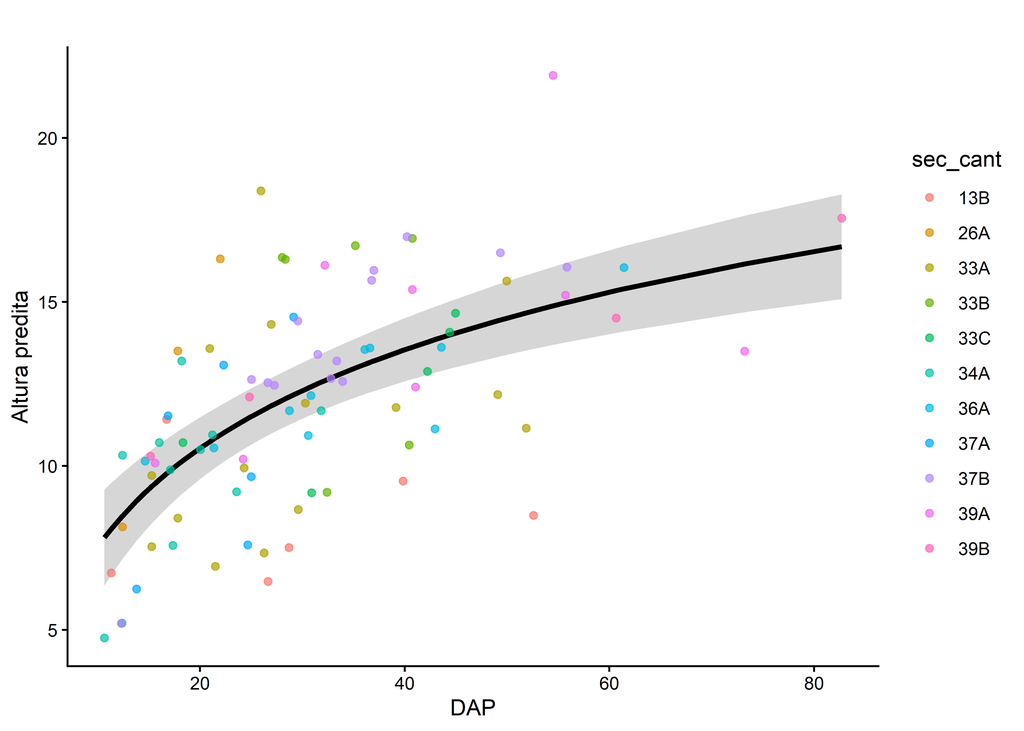

```r
# Predicting for plotting
pred_mod1mb <- ggpredict(mod1mb, terms = "dap [all]", type = "fixed")

# Visualizing
ggplot(pred_mod1mb, aes(x = x, y = predicted)) +
  geom_ribbon(aes(ymin = conf.low, ymax = conf.high), alpha = 0.2) +
  geom_line(linewidth = 1.2) +
  geom_point(data = bignoniaceae, aes(x = dap, y = altura, color = sec_cant), inherit.aes = FALSE, alpha = 0.7) +
  labs(x = "DAP", y = "Altura predita", title = "") +
  theme_classic()
```

```r
# Extraindo efeitos aleatórios dos canteiros
rank_canteiros_b <- ranef(mod1mb)$sec_cant %>%
  as.data.frame() %>%
  rownames_to_column("sec_cant") %>%
  rename(efeito_canteiro = `(Intercept)`) %>%
  arrange(desc(efeito_canteiro)) %>%
  mutate(rank = row_number(), interpretacao = case_when(efeito_canteiro > 0 ~ "Acima da média",
      efeito_canteiro < 0 ~ "Abaixo da média",
      TRUE ~ "Na média"))
```

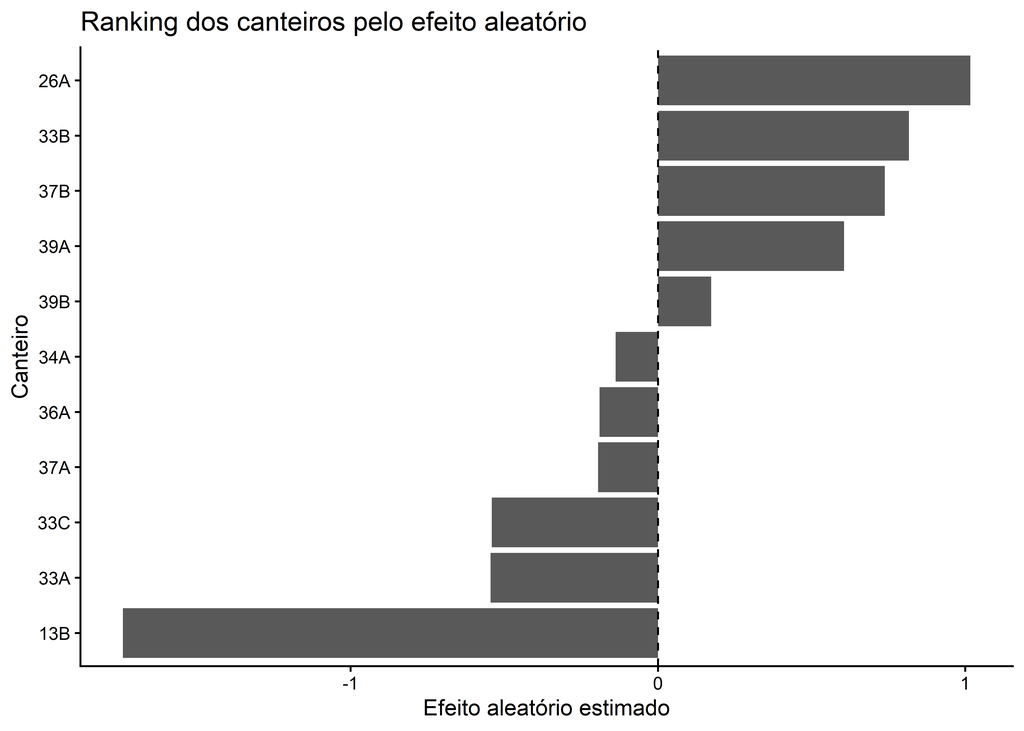

```r
# Visualizando
ggplot(rank_canteiros_b, aes(x = reorder(sec_cant, efeito_canteiro), y = efeito_canteiro)) +
  geom_col() +
  geom_hline(yintercept = 0, linetype = "dashed") +
  coord_flip() +
  labs(x = "Canteiro", y = "Efeito aleatório estimado", title = "Ranking dos canteiros pelo efeito aleatório") +
  theme_classic()
```

### 🔴 Sugestão do professor:

Como comentado antes, a comparação por anova() deve ser restrita aos modelos aninhados, como o linear e o quadrático. A comparação entre as formas linear, logarítmica e quadrática deve ser feita por AIC, BIC, R² ajustado e diagnóstico dos resíduos. Para comparar o modelo simples ao modelo misto por AIC e BIC, o modelo misto deve ser ajustado inicialmente por máxima verossimilhança (REML = FALSE). Por praticidade, não farei novamente essa correção, mas deixo claro que esse erro de comparação dos modelos também se repete nas seções posteriores.

```r
# Comparação entre os modelos simples
# A ANOVA é válida apenas entre os modelos linear e quadrático
anova(mod1b_alt, mod2b_alt)
```

```
## Analysis of Variance Table
##
## Model 1: altura ~ dap
## Model 2: altura ~ dap + I(dap^2)
##   Res.Df    RSS Df Sum of Sq      F  Pr(>F)
## 1     86 654.83
## 2     85 614.44  1    40.391 5.5876 0.02037 *
## ---
## Signif. codes:  0 '***' 0.001 '**' 0.01 '*' 0.05 '.' 0.1 ' ' 1
```

```r
# Comparação geral entre modelos lineares, logarítmicos e quadráticos
AIC(mod1b_alt, mod_logb_alt, mod2b_alt)
```

```
##              df      AIC
## mod1b_alt     3 432.3529
## mod_logb_alt  3 424.8924
## mod2b_alt     4 428.7503
```

```r
# BIC
BIC(mod1b_alt, mod_logb_alt, mod2b_alt)
```

```
##              df      BIC
## mod1b_alt     3 439.7849
## mod_logb_alt  3 432.3244
## mod2b_alt     4 438.6596
```

```r
# R² ajustado dos modelos
r2(mod1b_alt)
```

```
## # R2 for Linear Regression
##        R2: 0.334
##   adj. R2: 0.326
```

```r
r2(mod_logb_alt)
```

```
## # R2 for Linear Regression
##        R2: 0.388
##   adj. R2: 0.381
```

```r
r2(mod2b_alt)
```

```
## # R2 for Linear Regression
##        R2: 0.375
##   adj. R2: 0.360
```

```r
# Modelo misto ajustado por máxima verossimilhança para comparação
mod1mb_ml <- lmer(altura ~ log(dap) + (1 | sec_cant), data = bignoniaceae, REML = FALSE)

# Comparação entre os modelos sem e com efeito de canteiro
AIC(mod_logb_alt, mod1mb_ml)
```

```
##              df      AIC
## mod_logb_alt  3 424.8924
## mod1mb_ml     4 424.5459
```

```r
# BIC
BIC(mod_logb_alt, mod1mb_ml)
```

```
##              df      BIC
## mod_logb_alt  3 432.3244
## mod1mb_ml     4 434.4552
```

```r
# Avaliação do efeito aleatório
ranova(mod1mb_ml)
```

```
## ANOVA-like table for random-effects: Single term deletions
##
## Model:
## altura ~ log(dap) + (1 | sec_cant)
##                npar  logLik    AIC    LRT Df Pr(>Chisq)
## <none>            4 -208.27 424.55
## (1 | sec_cant)    3 -209.45 424.89 2.3465  1     0.1256
```

```r
# R² marginal e condicional
r2(mod1mb_ml)
```

```
## # R2 for Mixed Models
##
##   Conditional R2: 0.447
##      Marginal R2: 0.366
```

#### 3.4.2.4. Explorando outros gêneros

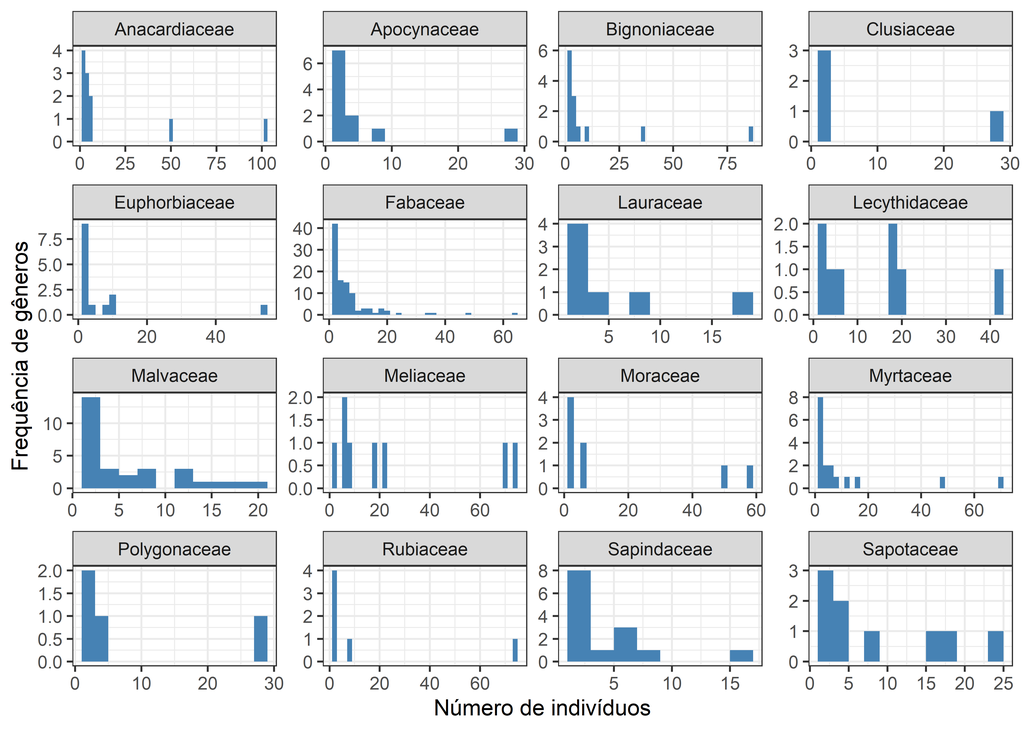

```r
arv_16 %>%
  group_by(family, genus) %>%
  summarise(n = n()) %>%
  ggplot(aes(x = n)) +
  geom_histogram(binwidth = 2, fill = "steelblue") +
  facet_wrap(~ family, scales = "free") +
  labs(x = "Número de indivíduos", y = "Frequência de gêneros") +
  theme_bw()
```

```r
arv_16 %>%
  group_by(family, genus) %>%
  summarise(n = n()) %>%
  pull(n) %>%
  quantile(probs = c(0.25, 0.5, 0.75, 0.9))
```

```
##  25%  50%  75%  90%
##  1.0  4.0  9.0 19.6
```

### 🔴 Sugestão do professor:

Esse gráfico não fez o menor sentido de ter sido colocado aqui nesse ponto do código.

#### 3.4.2.5. Malvaceae

```r
# Filtering for genus and beds with more than 3 plants
malvaceae <- arvore %>%
  filter(family == "Malvaceae") %>%
  filter(!is.na(genus)) %>%
  add_count(genus, name = "n_genus") %>%
  filter(n_genus >= 3) %>%
  add_count(sec_cant, name = "n_sec_cant") %>%
  filter(n_sec_cant >= 3) %>%
  dplyr::select(-n_genus, -n_sec_cant)
```

##### 3.4.2.5.1 - Linear model

```r
# Linear model
mod1ma <- lm(altura ~ dap + genus, data = malvaceae)
```

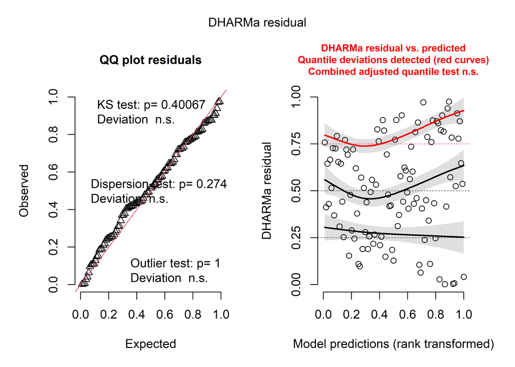

```r
# Analysis of residuals
res_mod1ma <- simulateResiduals(mod1ma, n = 1000)
plot(res_mod1ma)
```

```r
# Linear model ANOVA
anova(mod1ma)
```

```
## Analysis of Variance Table
##
## Response: altura
##           Df Sum Sq Mean Sq  F value    Pr(>F)
## dap        1 3640.6  3640.6 192.8796 < 2.2e-16 ***
## genus     14  958.0    68.4   3.6255 9.694e-05 ***
## Residuals 88 1661.0    18.9
## ---
## Signif. codes:  0 '***' 0.001 '**' 0.01 '*' 0.05 '.' 0.1 ' ' 1
```

```r
# Linear model summary
summary(mod1ma)
```

```
##
## Call:
## lm(formula = altura ~ dap + genus, data = malvaceae)
##
## Residuals:
##      Min       1Q   Median       3Q      Max
## -13.1501  -2.5020   0.0965   2.9442   8.2321
##
## Coefficients:
##                   Estimate Std. Error t value Pr(>|t|)
## (Intercept)        6.06915    1.48389   4.090 9.52e-05 ***
## dap                0.14789    0.01385  10.679  < 2e-16 ***
## genusCavanillesia -3.17556    4.96927  -0.639 0.524458
## genusCeiba         4.29142    2.01783   2.127 0.036240 *
## genusCola         -0.11299    2.11434  -0.053 0.957501
## genusEriotheca     2.52344    2.89657   0.871 0.386026
## genusGuazuma      -4.50173    2.48720  -1.810 0.073715 .
## genusHydrogaster  -0.41659    2.89906  -0.144 0.886067
## genusLuehea        2.37086    2.20975   1.073 0.286247
## genusPachira      -3.19571    2.23908  -1.427 0.157049
## genusPatinoa       0.93932    2.90267   0.324 0.747006
## genusPseudobombax -2.25224    2.24488  -1.003 0.318478
## genusPterospermum -0.44410    2.92298  -0.152 0.879586
## genusPterygota     7.55267    2.13519   3.537 0.000648 ***
## genusSterculia     3.01141    2.02923   1.484 0.141378
## genusTheobroma     0.72589    1.85668   0.391 0.696772
## ---
## Signif. codes:  0 '***' 0.001 '**' 0.01 '*' 0.05 '.' 0.1 ' ' 1
##
## Residual standard error: 4.345 on 88 degrees of freedom
## Multiple R-squared:  0.7346, Adjusted R-squared:  0.6894
## F-statistic: 16.24 on 15 and 88 DF,  p-value: < 2.2e-16
```

```r
# Log model
mod_logma <- lm(altura ~ log(dap) + genus, data = malvaceae)
```

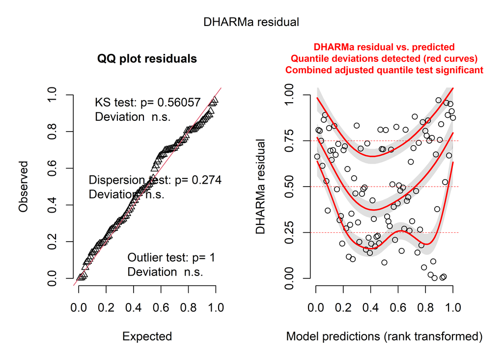

```r
# Analysis of residuals
res_mod_logma <- simulateResiduals(mod_logma, n = 1000)
plot(res_mod_logma)
```

##### 3.4.2.5.2. Quadract model

```r
# Quadratic model
mod2ma <- lm(altura ~ dap + I(dap^2) + genus, data = malvaceae)
```

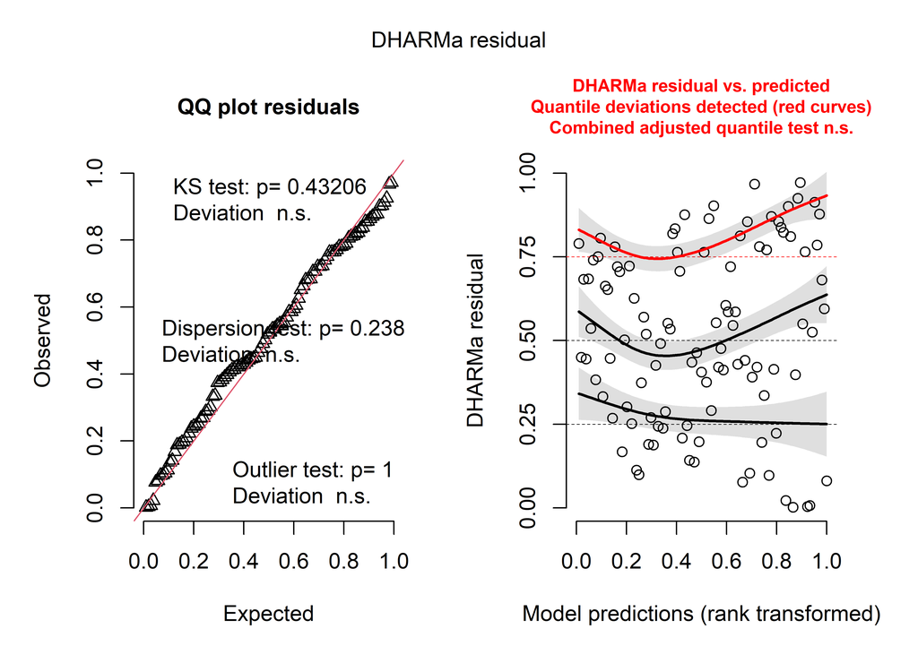

```r
# Analysis of residuals
res_mod2ma <- simulateResiduals(mod2ma, n = 1000)
plot(res_mod2ma)
```

```r
# Quadratic model ANOVA
anova(mod2ma)
```

```
## Analysis of Variance Table
##
## Response: altura
##           Df Sum Sq Mean Sq  F value    Pr(>F)
## dap        1 3640.6  3640.6 191.5086 < 2.2e-16 ***
## I(dap^2)   1    0.8     0.8   0.0431 0.8360695
## genus     14  964.3    68.9   3.6234 0.0001001 ***
## Residuals 87 1653.9    19.0
## ---
## Signif. codes:  0 '***' 0.001 '**' 0.01 '*' 0.05 '.' 0.1 ' ' 1
```

#####3.4.2.5.3. Comparing models

```r
# ANOVA for comparing linear, quadratic and log regression models
anova(mod1ma, mod2ma, mod_logma)
```

```
## Analysis of Variance Table
##
## Model 1: altura ~ dap + genus
## Model 2: altura ~ dap + I(dap^2) + genus
## Model 3: altura ~ log(dap) + genus
##   Res.Df    RSS Df Sum of Sq       F    Pr(>F)
## 1     88 1661.0
## 2     87 1653.9  1      7.12  0.3745    0.5422
## 3     88 1973.0 -1   -319.16 16.7890 9.345e-05 ***
## ---
## Signif. codes:  0 '***' 0.001 '**' 0.01 '*' 0.05 '.' 0.1 ' ' 1
```

```r
# AIC and BIC for model comparison
AIC(mod1ma, mod2ma, mod_logma)
```

```
##           df      AIC
## mod1ma    17 617.3012
## mod2ma    18 618.8545
## mod_logma 17 635.2054
```

```r
BIC(mod1ma, mod2ma, mod_logma)
```

```
##           df      BIC
## mod1ma    17 662.2558
## mod2ma    18 666.4535
## mod_logma 17 680.1601
```

```r
# Linear model R²
r2(mod1ma)
```

```
## # R2 for Linear Regression
##        R2: 0.735
##   adj. R2: 0.689
```

```r
# log model R²
r2(mod_logma)
```

```
## # R2 for Linear Regression
##        R2: 0.685
##   adj. R2: 0.631
```

##### 3.4.2.5.4. Visualizing results

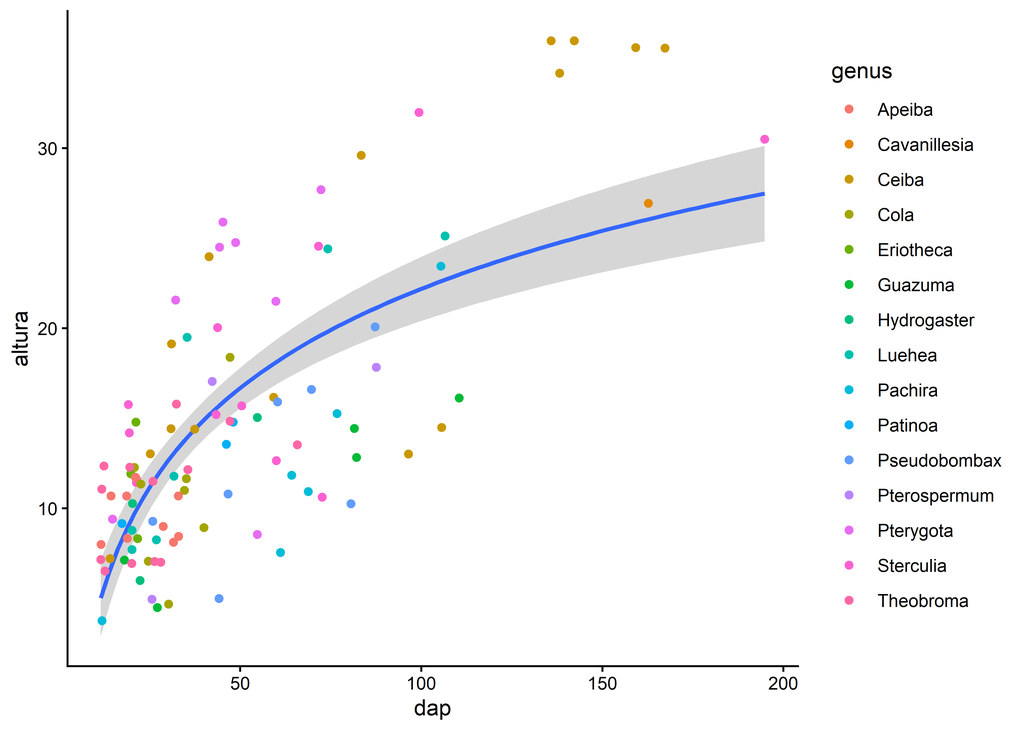

```r
ggplot(data = malvaceae, aes(x = dap, y = altura)) +
  geom_smooth(method = "lm", formula = y ~ log(x)) +
  geom_point(aes(color = genus)) +
  theme_classic()
```

### 🔴 Sugestão do professor:

Além dos aspectos de comparação do modelo registrados na seção acima, os resultados da comparação favorecem o modelo linear, enquanto o gráfico final apresenta uma relação logarítmica. O gráfico deve representar o modelo selecionado. Como o modelo inclui gênero, também devem ser apresentadas as predições específicas para cada gênero, e não uma única curva geral.

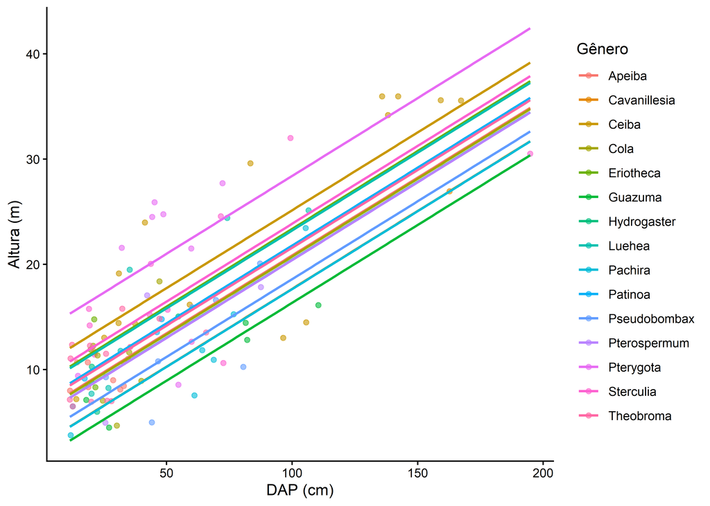

```r
# Criando a base para predição
newdata_ma <- expand.grid(dap = seq(min(malvaceae$dap, na.rm = TRUE), max(malvaceae$dap, na.rm = TRUE), length.out = 100), genus = mod1ma$xlevels$genus)

# Alturas preditas pelo modelo
newdata_ma$pred <- predict(mod1ma, newdata = newdata_ma)

# Visualizando
ggplot(malvaceae, aes(x = dap, y = altura)) +
  geom_point(aes(color = genus), alpha = 0.6) +
  geom_line(data = newdata_ma, aes(y = pred, color = genus), linewidth = 0.8) +
  labs(x = "DAP (cm)", y = "Altura (m)", color = "Gênero") +
  theme_classic()
```